# Project Peer Review

due Mon, Nov 22 at 11:59pm

Critically reviewing others’ work is a crucial part of the scientific process, and STA 199 is no exception. Each group has been given read access to another group’s repo to review and provide feedback on their project draft. This review is intended to help you create a high quality final project, as well as give you experience reading and constructively critiquing the work of others.

To ensure the group has enough time to start incorporating feedback ,you should work on the peer review during lab and submit comments by **Monday, November 22 at 11:59pm**.

# Getting started

[Click here](https://prodduke-my.sharepoint.com/:x:/g/personal/mt324_duke_edu/ESq8ffmF8L5MhXcTJx7jOPUBMiLbWxc3AR7fGa9gTMZRXQ?e=VkKWgG) to see which project you’re reviewing.

In GitHub, search the repositories for project, and you should see the repo for the project you’re reviewing. You will be able to read the files in the repo and post issues, but you cannot push changes to the repo. You will have access to the repo until the deadline for the peer review.

# Reviewing the draft

Carefully read the project draft, and consider the questions below as you read it.

Once you’ve read the draft, you will submit the review for each part by opening new **Issues** in the team’s repo. To open and submit an issue: - Go to the team’s repo and click **Issues**.

[figure not shown]

- Click **New issue**.
- You will see one template for each part of the peer review. Click **Get started** and it will open a new issue.

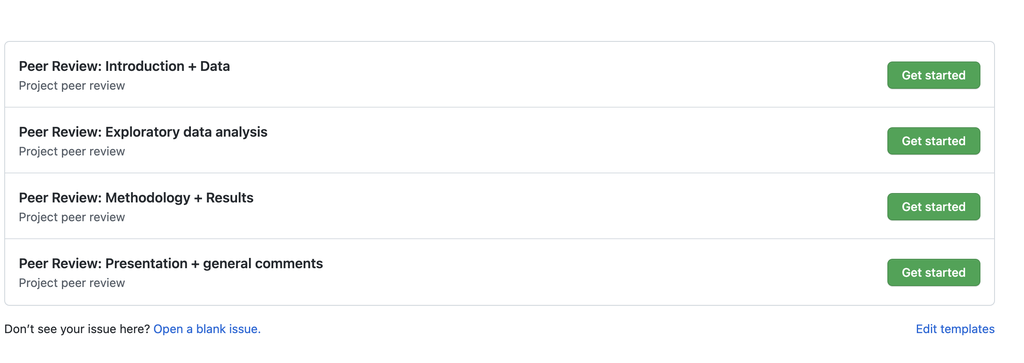

- Type your response to each question.
- When you’ve completed the review, click **Submit new issue**, and you are done with that part of the review.

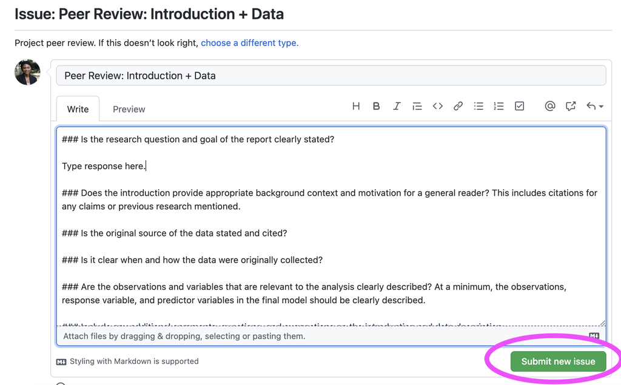

- Repeat this for all four parts of the review.

# Peer review questions

Your response to each question in the peer review has two parts:

1️⃣ Selection of one of the following:

- **Yes**: The item is clearly and accurately completed in the draft.
- **Somewhat**: There is an attempt to complete the item in the draft; however, it is incomplete or there are some inaccuracies.
- **No**: There is no attempt to complete the item in the draft, or there are major inaccuracies.

2️⃣ Brief comment about your selection.

- If you responded **Yes**, briefly summarize the answer from the draft. For example, if you answer **yes** that the draft includes citations for outside research, briefly summarize what the outside research is.
- If you responded **Somewhat** or **No**, briefly summarize what is incomplete or inaccurate. In other words, briefly summarize why you did not respond Yes to that item.

## Issue 1: Introduction + Data

- Is the research question and goal of the report clearly stated?
- Does the introduction provide appropriate background context and motivation for a general reader?
- Is the source of the data stated with an appropriate citation?
- Is it clear when and how the data was originally collected?
- Are the observations and relevant variables described?
- Include any additional comments, questions, or suggestions on the introduction and data description.

## Issue 2: Exploratory data analysis

- Is the data cleaning and data wrangling clearly described? This includes dealing with missing data, creating new variables, etc.
- Do the visualizations follow the guidelines we’ve discussed in STA 199? This includes using plots that are appropriate for the data, having proper axis labels, titles, etc.
- Are any tables and figures clear, effective, and informative? Should any be eliminated, or are any new tables or figures needed?
- Include any additional comments, questions, or suggestions for the exploratory data analysis.

## Issue 3: Methodology + Results

- Are the chosen methods (e.g. hypothesis testing, confidence intervals, models, etc.) for answering the research question appropriate for the research context and type of data?
- Is the research question answered accurately and effectively?
- Is the answer to the research question summarized and supported by statistical arguments?
- Include any additional comments, questions, or suggestions for the methodology and results.

- Is the paper professionally presented and generally free of distracting errors or other issues, including (but not limited to) insufficient organization or formatting; poor grammar, spelling, or punctuation; or too-small font? Is the overall paper easily readable for someone with your expert level of knowledge? Note any concerns here.
- Knit the .Rmd file. Are you able to reproduce all aspects of the report, including output, visualizations, etc? This includes (1) being able to knit the document and (2) obtaining the same PDF as the original PDF.
- What questions and/or general feedback do you have for the authors?

# Applying what you’ve learned to your project

**Discuss the following as a group. You do not need to submit a response to this question.**

After giving feedback to this group, what is one thing you want to change or continue working on for your report?

# Submission

The peer review will be graded on the extent to which it comprehensively and constructively addresses the components of the partner team’s report: the research context and motivation, exploratory data analysis, reproducibility, and any inference, modeling, or conclusions.

You will be graded based on the feedback in the issues submitted on GitHub.